# KNN

## KNN Algorithm with Python

## 1. Exploratory Data Analysis

For this implementation we are going to be working with the **Wine** dataset. This is a 178 sample dataset that categorises 3 different types of Italian wine using 13 different features. The code below loads the Wine dataset and selects a subset of features for you to work with.

```python
# set matplotlib backend to inline
%matplotlib inline

# import modules
from sklearn import datasets
import numpy as np
import matplotlib.pyplot as plt
import pandas as pd

# load data
wine=datasets.load_wine()

# this dataset has 13 features, we will only choose a subset of these
df_wine = pd.DataFrame(wine.data, columns = wine.feature_names )
selected_features = ['alcohol','flavanoids','color_intensity','ash']

# extract the data as numpy arrays of features, X, and target, y
X = df_wine[selected_features].values
y = wine.target

df_wine.head()
```

|  | alcohol | malic_acid | ash | alcalinity_of_ash | magnesium | total_phenols | flavanoids | nonflavanoid_phenols | proanthocyanins | color_intensity | hue | od280/od315_of_diluted_wines | proline |
| --- | --- | --- | --- | --- | --- | --- | --- | --- | --- | --- | --- | --- | --- |
| 0 | 14.23 | 1.71 | 2.43 | 15.6 | 127.0 | 2.80 | 3.06 | 0.28 | 2.29 | 5.64 | 1.04 | 3.92 | 1065.0 |
| 1 | 13.20 | 1.78 | 2.14 | 11.2 | 100.0 | 2.65 | 2.76 | 0.26 | 1.28 | 4.38 | 1.05 | 3.40 | 1050.0 |
| 2 | 13.16 | 2.36 | 2.67 | 18.6 | 101.0 | 2.80 | 3.24 | 0.30 | 2.81 | 5.68 | 1.03 | 3.17 | 1185.0 |
| 3 | 14.37 | 1.95 | 2.50 | 16.8 | 113.0 | 3.85 | 3.49 | 0.24 | 2.18 | 7.80 | 0.86 | 3.45 | 1480.0 |
| 4 | 13.24 | 2.59 | 2.87 | 21.0 | 118.0 | 2.80 | 2.69 | 0.39 | 1.82 | 4.32 | 1.04 | 2.93 | 735.0 |

### 1.1. Visualising the data

The first part of tackling any ML problem is visualising the data in order to understand some of the properties of the problem at hand. When there are only a small number of classes and features, it is possible to use scatter plots to visualise interactions between different pairings of features.

Your first task is to recreate a similar grid for the **Wine** dataset, with each off-diagonal subplot showing the interaction between two features, and each of the classes represented as a different colour. The on-diagonal subplots (representing a single feature) should show a distribution (or histogram) for that feature.

You should create a function that, given data X and labels y, plots this grid. The function should be invoked something like this:

```
myplotGrid(X,y,...)
```

where X is your training data and y are the labels (you may also supply additional optional arguments). You can use an appropriate library to help you create the visualisation. You might want to code it yourself using matplotlib functions scatter and hist - however, this is not strictly necessary here, so try not spend too much time on this.

```python
# Import chosen visualisation library
import seaborn as sns
from IPython.display import display, Markdown

# define plotting function
def myplotGrid(X, y, features, hue = "Class", palette = "Set1"):
    '''
    Creates a multi-plot grid using Seaborn from passed data and labels.

            Inputs:
                    X (array): The training data
                    y (array): The labels
                    features (list): A subset of features of our data to use
                    hue (str, optional): Display name of for what the colours are mapped to
                    palette (str, optional): The name of the Seaborn palette to use

            Outputs:
                    void
    '''
    data = np.c_[X, y]; # Concat the data with the target
    cols = np.append(selected_features, [hue]) # Add a column name for our target
    df = pd.DataFrame(data, columns = cols)
    sns.pairplot(df, hue = hue, vars = features, palette = palette) # Plot the graph
```

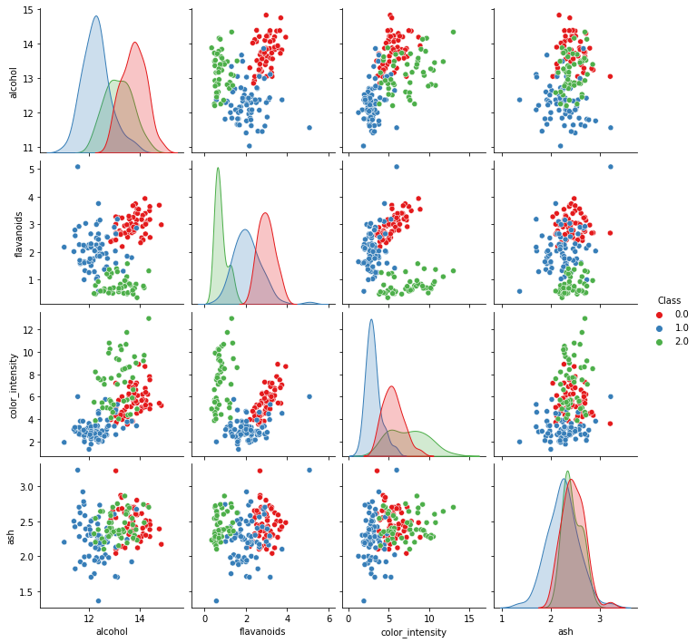

```python
# run the plotting function
myplotGrid(X, y, selected_features)
```

### 1.2. Exploratory Data Analysis under noise

When data are collected under real-world settings they usually contain some amount of noise that makes classification more challenging. In the cell below, invoke your exploratory data analysis function above on a noisy version of your data X.

Try to perturb your data with some Gaussian noise,

```
# initialize random seed to replicate results over different runs
mySeed = 12345
np.random.seed(mySeed)
XN=X+np.random.normal(0,0.6,X.shape)
```

and then invoke

```
myplotGrid(XN,y)
```

```python
# initialize random seed to replicate results over different runs
mySeed = 12345
np.random.seed(mySeed)
XN = X + np.random.normal(0, 0.6, X.shape)
```

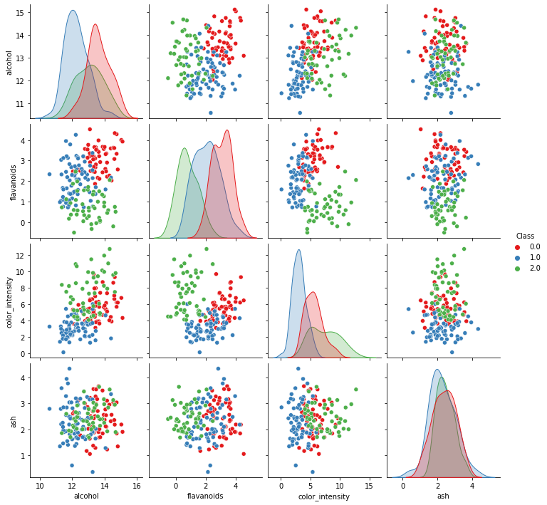

```python
# run plotting function using noisy version of the data
myplotGrid(XN, y, selected_features)
```

### Q1. Exploratory data analysis

Based on your exploratory analysis, if you were to build a classifier using only two of the available features, which ones would you choose and why? Answer as fully as you can.

Answer: If I was to build a classifier using only two of the features, I would choose alcohol and flavanoids. If we look at the outputs for the other combinations, we can see a great deal of overlap. This overlap ranges from flavanoids and color (sic) intensity, where we see where we see a lot of overlap between the first and second classes, to something like alcohol and ash, where the outputs are very heavily clustered together. Alchol and flavanoids, however, have a much more distinct output, where distinguishing between the three classes is less difficult. We can infer from this, then, that we could make clearer distinctions and more accurate predictions.

That said, if we examine the same data under noise, the choice is a little more difficult. There is much more overlap in the graphs showing alcohol and flavanoids. So much so, that we might decide that using flavanoids and color (sic) intensity would be more accurate.

### Q2. Data with noise

What do you observe by plotting the data without noise compared to plotting with added Gaussian noise?

Answer: As mentioned earlier, it is quite clear that adding noise make the outputs much less clear, and more difficult to distinguish. Alcohol and flavanoids is far clearer without noise that it is with. Further, the outputs for alcohol and ash, after noise is added, are completely mixed making that combination of features arguably useless for making predictions. Simply put, adding noise would lead to much less accurate classification. We could possibly counter this using much higher values of K in our KNN algorithm.

## 2. Implementing kNN

In the cell below, develop your own code for performing k-Nearest Neighbour classification. You may use the scikit-learn k-NN implementation from the labs as a guide - and as a way of verifying your results - but it is important that your implementation does not use any libraries other than the basic numpy and matplotlib functions.

Define a function that performs k-NN given a set of data. Your function should be invoked similary to:

```
    y_ = mykNN(X,y,X_,options)
```

where X is your training data, y is your training outputs, X_ are your testing data and y_ are your predicted outputs for X_. The options argument (can be a list or a set of separate arguments depending on how you choose to implement the function) should at least contain the number of neighbours to consider as well as the distance function employed.

Hint: it helps to break the problem into various sub-problems, implemented as helper function. For example, you might want to implement separate function(s) for calculating the distances between two vectors. And another function that uncovers the nearest neighbour(s) to a given vector.

```python
def euclidean_distance(point1, point2):
    '''
    Calculates the Euclidean distance between two points.

            Inputs:
                    point1 (array): Point 1
                    point2 (array): Point 2

            Outputs:
                    distance (float64): The Euclidian distance between x1 and x2
    '''
    distance = 0
    for i in range(len(point1)):
        distance = distance + np.square(point1[i]-point2[i])
    return np.sqrt(distance)

def manhattan_distance(point1, point2):
    '''
    Calculates the Manhattan distance between two points.

            Inputs:
                    point1 (array): Point 1
                    point2 (array): Point 2

            Outputs:
                    distance (float64): The Manhattan distance between x1 and x2
    '''
    distance = 0
    for i in range(len(point1)):
        distance = distance + abs(point1[i]-point2[i])
    return distance;

def minkowski_distance(point1, point2):
    '''
    Calculates the Minkowski distance between two points.

            Inputs:
                    point1 (array): Point 1
                    point2 (array): Point 2

            Outputs:
                    distance (float64): The Minkowski distance between x1 and x2
    '''
    distance = 0
    for i in range(len(point1)):
        distance = distance + abs(point1[i]-point2[i])**2
    return np.sqrt(distance)**(1/2)

def compute_distance(point, points, distance_function):
    '''
    Returns the distances between one point (point) and all other points (points) using the distance_function.

            Inputs:
                    point (array): The point to calculate distance from
                    points (array): The points to calculate the distances to
                    distance_function (function): Function to use for calculating the distance

            Outputs:
                    distance (list): The distances
    '''
    return [distance_function(point, points) for points in points]

def first_n_items(amounts, y, k):
    '''
    Gets the indices of the k smallest numbers in amounts, and returns the items with those indeces in y.

            Inputs:
                    amounts (list): List of the numbers used for sorting
                    y (array): The array of items to which the indices correspond
                    k (int): The number of items to return

            Outputs:
                    items (list): The n number of items corresponding to the smallest values in amounts
    '''
    n_indices = np.argsort(amounts)[:k] # Sort the array (so we get the smallest first) and return n items
    return [y[i] for i in n_indices]

def most_occurrences(arr):
    '''
    Returns the number of occurrences of each item in an array (arr).

            Inputs:
                    arr (list): The array to investigate

            Outputs:
                    occurrences (numpy.ndarray): Array containing the amount of occurrences
    '''
    return np.bincount(arr) # Use numpy to calculate counts

def train_test_split_data(data, target, test_size=0.2):
    '''
    Split arrays or matrices into subsets of random train and test data.

            Inputs:
                    data (matrix): The array to investigate
                    target (array): The array to investigate
                    test_size (int, optional): The array to investigate

            Outputs:
                    X_train (array): List containing X train set of inputs
                    X_test (array): List containing X test set of inputs
                    y_train (array): List containing Y train set of inputs
                    y_test (array, optional): List containing Y test set of inputs
    '''
    i = int((1 - test_size) * data.shape[0])
    shuf = np.random.permutation(data.shape[0])

    X_train, X_test = np.split(np.take(data, shuf, axis=0), [i])
    y_train, y_test = np.split(np.take(target, shuf), [i])
    return X_train, X_test, y_train, y_test
```

```python
# Set up vars
nearest_neighbours = 3 # The nearest neightbours to grab
X, y = df_wine[selected_features].values, wine.target # The data we're using for KNN

# Using custom function, create train and test data sets
X_train, X_test, y_train, y_test = train_test_split_data(X, y, test_size = 0.2)
```

```python
# mykNN code
def mykNN(X, y, X_, k, distance_function):
    '''
    Implementation of KNN K-nearest-neighbours.

            Inputs:
                    X (matrix): The training set
                    y (array): The targets for the training set
                    X_ (array): The testing set
                    k (int): The amount of neighbours to use
                    distance_function (function): The distance function to use for comparisons

            Outputs:
                    predictions (array): The list of predictions
    '''
    def predict(x):
        # Calculate the distances
        distances = compute_distance(x, X, distance_function)
        # Get k nearest labels
        k_nearest_labels = first_n_items(distances, y, k)
        # Get the number of times each label appears
        most_common = most_occurrences(k_nearest_labels)
        # Return the most common label
        return np.argmax(most_common)

    # Make the predictions
    predictions = [predict(x) for x in X_]
    return np.array(predictions)

# Invoke myKNN code
y_ = mykNN(X_train, y_train, X_test, 3, euclidean_distance)
```

### Evaluating the mykNN alogorithm

We can verify the results of the KNN algorith above by comparing it to the results achieved with scikit-learn, as follows.

```python
from sklearn.neighbors import KNeighborsClassifier
from sklearn.metrics import accuracy_score

# scikit-learn KNN implementation
sklearn_clf = KNeighborsClassifier(nearest_neighbours)
sklearn_clf.fit(X_train, y_train)
sklearn_predictions = sklearn_clf.predict(X_test)

display(Markdown('#### --- myKNN implementation ---'))
display(Markdown('Accuracy score: ' + str(accuracy_score(y_test, y_))))
display(Markdown('Predictions: ' + str(y_)))

display(Markdown('---'))

display(Markdown('#### --- scikit-learn KNN implementation results ---'))
display(Markdown('Accuracy score: ' + str(accuracy_score(y_test, sklearn_predictions))))
display(Markdown('Predictions: ' + str(sklearn_predictions)))
```

--- myKNN implementation ---

Accuracy score: 0.9166666666666666

Predictions: [1 1 1 1 0 0 2 0 0 0 1 2 1 0 0 1 2 0 0 0 0 0 2 1 1 0 0 0 1 1 2 1 0 2 1 2]

--- scikit-learn KNN implementation results ---

Accuracy score: 0.9166666666666666

Predictions: [1 1 1 1 0 0 2 0 0 0 1 2 1 0 0 1 2 0 0 0 0 0 2 1 1 0 0 0 1 1 2 1 0 2 1 2]

As we can see, the results are identical.

## 3. Classifier evaluation

In the cell below, implement your own classifier evaluation code. This should include some way of calculating confusion matrices, as well as common metrics like accuracy.

Write some additional code that lets you display the output of your confusion matrices in a useful and easy-to-read manner.

You might want to test your functions on some test data, and compare the results to the sklearn library versions.

```python
# confusion matrix, accuracy, precision, recall, etc.
def accuracy(actual, predictions):
    '''
    Returns accuracy score of predictions to actual data.

            Inputs:
                    actual (array): The actual data
                    predictions (array): The predictions

            Outputs:
                    accuracy (float64): The accuracy score
    '''
    return np.sum(predictions == actual) / len(actual)

def accuracy_as_percentage(actual, predictions):
    '''
    Returns accuracy score of predictions to actual data, as a percentage.

            Inputs:
                    actual (array): The actual data
                    predictions (array): The predictions

            Outputs:
                    accuracy (float64): The accuracy score
    '''
    return accuracy(actual, predictions) * 100

def create_confusion_matrix(actual, predictions, target):
    '''
    Returns a confusion matrix for the passed predictions.

            Inputs:
                    actual (array): The actual data
                    predictions (array): The predictions
                    target (array): The target data

            Outputs:
                    matrix (matrix): The confusion matrix
    '''
    size = len(np.unique(y)) # The number of classes
    matrix = np.zeros((size, size), dtype = int) # Creates empty matrix
    for i in range(0, len(actual)):
        matrix[actual[i], predictions[i]] += 1 # Populate matrix

    return matrix

def create_confusion_matrix_pretty(matrix, subplot = [1, 2, 1], cmap = 'Greens', title = None):
    '''
    Returns a confusion matrix visualisaion usinging matplotlib.

            Inputs:
                    matrix (matrix): The matrix data
                    subplot (array, optional): Vis subplot
                    cmap (str, optional): The colour map to use
                    title (str, optional): The title for the vis

            Outputs:
                    void
    '''
    plt.figure(figsize=(15,6))
    plt.subplot(*subplot)
    if title:
        plt.title(title)
    sns.heatmap(matrix, annot = True, cmap = cmap, cbar = False);
    plt.xlabel('Predicted labels');
    plt.ylabel('Actual labels');

def recall(cf, format=False):
    '''
    Returns the recall score for a given confusion matrix.

            Inputs:
                    cf (matrix): A confusion matrix
                    format (bool, optional): Whether to format the results, rounded to two decimal places

            Outputs:
                    average, scores (float, array): Average recall, and all recall scores
    '''
    recalls = []
    for index, row in enumerate(cf):
        total = row.sum()
        total_tp = row[index]
        places = 2 if format else 8
        result = round(total_tp/total, places)
        recalls.append(float(result))
    avg = round(sum(recalls)/len(recalls), places) if format else sum(recalls)/len(recalls)
    return (float(avg), recalls)

def precision(cf, format=False):
    '''
    Returns the precision score for a given confusion matrix.

            Inputs:
                    cf (matrix): A confusion matrix
                    format (bool, optional): Whether to format the results, rounded to two decimal places

            Outputs:
                    average, scores (float, array): Average recall, and all precision scores
    '''
    precisions = []
    for index, row in enumerate(cf.transpose()):
        total = row.sum()
        total_tp = row[index]
        places = 2 if format else 8
        result = round(total_tp/total, places)
        precisions.append(float(result))
    avg = round(sum(precisions)/len(precisions), places) if format else sum(precisions)/len(precisions)
    return (float(avg), precisions)

def f1(cf, format=False):
    '''
    Returns the f1 score for a given confusion matrix.

            Inputs:
                    cf (matrix): A confusion matrix
                    format (bool, optional): Whether to format the results, rounded to two decimal places

            Outputs:
                    result (float): The average F1 score
    '''
    places = 2 if format else 8
    avg_precision, precisions = precision(cf)
    avg_recall, recalls = recall(cf)
    f1s = []
    for i, p in enumerate(precisions, start=0):
        result = round((2*precisions[i]*recalls[i]) / (precisions[i] + recalls[i]), places)
        f1s.append(float(result))
    avg = round((2*avg_precision*avg_recall) / (avg_precision + avg_recall), places)
    return (float(avg), f1s)
```

### Testing the evaluation code

We can verify the results of the evaluation code by comparing it to the results achieved with scikit-learn, as follows.

--- My results ---

Accuracy score: 0.9166666666666666

Precision: 0.88392857

Recall: 0.9375

Precision (classes): [0.9375, 1.0, 0.71428571]

Recall (classes): [1.0, 0.8125, 1.0]

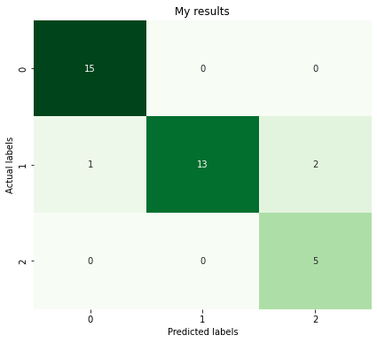

```python
# test evaluation code - My code
cf = create_confusion_matrix(y_test, y_, y) # Create confusion matrix to pass to later functions

display(Markdown('#### --- My results ---'))
display(Markdown('Accuracy score: ' + str(accuracy(y_test, y_))))
precision_avg, precision_all = precision(cf)
recall_avg, recall_all = recall(cf)
display(Markdown('Precision: ' + str(precision_avg)))
display(Markdown('Recall: ' + str(recall_avg)))
display(Markdown('Precision (classes):  ' + str(precision_all)))
display(Markdown('Recall (classes):  ' + str(recall_all)))

create_confusion_matrix_pretty(cf, title ="My results")
```

--- scikit-learn results ---

Accuracy score: 0.9166666666666666

Precision: 0.8839285714285715

Recall: 0.9375

Precision (classes): [0.9375 1. 0.71428571]

Recall (classes): [1. 0.8125 1. ]

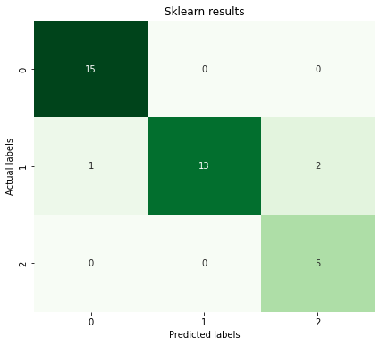

```python
# test evaluation code - Sklearn
from sklearn.metrics import precision_score
from sklearn.metrics import recall_score
from sklearn.metrics import f1_score
from sklearn.metrics import confusion_matrix
from sklearn.metrics import classification_report

display(Markdown('#### --- scikit-learn results ---'))
display(Markdown('Accuracy score: ' + str(accuracy_score(y_test, sklearn_predictions))))
display(Markdown('Precision: ' + str(precision_score(y_test, y_, average='macro'))))
display(Markdown('Recall: ' + str(recall_score(y_test, y_, average='macro'))))
display(Markdown('Precision (classes):  ' + str(precision_score(y_test, y_, average=None))))
display(Markdown('Recall (classes):  ' + str(recall_score(y_test, y_, average=None))))

sklearn_cf = confusion_matrix(y_test, sklearn_predictions) # Create confusion matrix to pass to later functions
create_confusion_matrix_pretty(sklearn_cf, title ="Sklearn results")
```

## 4. Nested Cross-validation using your implementation of KNN

In the cell below, develop your own code for performing 5-fold nested cross-validation along with your implemenation of k-NN above. You must write your own code -- the scikit-learn module may only be used for verification purposes.

Your code for nested cross-validation should invoke your kNN function (see above). You cross validation function should be invoked similary to:

```
accuracies_fold = myNestedCrossVal(X,y,5,list(range(1,11)),['euclidean','manhattan'],mySeed)
```

where X is your data matrix (containing all samples and features for each sample), 5 is the number of folds, y are your known output labels, `list(range(1,11)` evaluates the neighbour parameter from 1 to 10, and `['euclidean','manhattan',...]` evaluates the distances on the validation sets. mySeed is simply a random seed to enable us to replicate your results.

**Notes:**

- you should perform nested cross-validation on **both** your original data X, as well as the data pertrubed by noise as shown in the cells above (XN)
- you should evaluate **at least** two distance functions
- you should evaluate number of neighbours from 1 to 10
- your function should return a list of accuracies per fold
- for each **fold**, your function should print:
  - the accuracy per distinct set of parameters on the validation set
  - the best set of parameters for the fold after validation
  - the confusion matrix per fold (on the testing set)

```python
# myNestedCrossVal code
def getClassifier(actual, X, y, X_, k, distance_function):
    '''
    Create a KNN classifer and calculates it's accuracy

            Inputs:
                    actual (array): The actual data
                    X (matrix): The training set
                    y (array): The targets for the training set
                    X_ (array): The testing set
                    k (int): The amount of neighbours to use
                    distance_function (function): The distance function to use for comparisons

            Outputs:
                    accuracy, predictions (float64, list): The accuracy, list of predictions
    '''
    fn = euclidean_distance
    if (distance_function == 'manhattan'):
        fn = manhattan_distance
    elif (distance_function == 'minkowski'):
        fn = minkowski_distance

    y_pred =  mykNN(X, y, X_, k, fn)
    return (accuracy_score(actual, y_pred), y_pred)


def myNestedCrossVal(X, y, num_folds, neighbours, dist_funcs, mySeed):
    '''
    Performs nested cross validation of KNN.

            Inputs:
                    X (matrix): Data matrix input
                    y (array): Known output labels
                    num_folds (int): Number of folds to use
                    neighbours (list): Range of nearest neighbours
                    dist_funcs (list): List of distance functions to use
                    mySeed (int): Random seed

            Outputs:
                    fold_accuracy (list): List of accuracies
                    fold_params (list): List of best params
                    fold_matrix(ies) (list): List of confusion matrices
                    valset_accuracies (list): List of accuracies for each parameter set
    '''
    np.random.seed(mySeed)

    fold_accuracy = [] # Stores the accuracy of each fold
    fold_params = [] # Stores the best params for a fold
    fold_matrix = [] # Stores the fold matrix
    valset_accuracies = {} # Stores the accuracy per distinct set of parameters on the validation set

    # create a random list of indices corresponding to the size of the X
    indices = np.random.permutation( np.arange(0, len(X), 1) )

    # split the indices list into num_folds (our folds)
    bins = np.array_split(indices, num_folds)

    for index in range(0, num_folds):

        print('=================== Fold ' + str(index + 1) + ' ===================')
        print('Accuracy per distinct set of parameters on the validation set:')

        fold_train = [] # Store indices for training set
        fold_test = []  # Store indices for test set
        fold_val = []    # Store indices for validation set
        valset_accuracies[str(index)] = [] # Stores the param results for this fold

        # Loop through all bins
        val_bin = (index + 1) % num_folds # Calculate the 'next' bin after each iteration
        for b in range(0, len(bins)):
            if (index == b):
                fold_test = bins[index] # Store first bin for testing
            elif (b == val_bin):
                fold_val = bins[val_bin] # Store next bin for validation
            else:
                fold_train.extend( bins[b] ) # Store the rest for training

        most_accurate = -1 # Store most accurate per distinct set of parameters
        best_params_neighbours = 0 # Store best number of neighbours
        best_params_dist_funcs = '' # Store best distance function

        # Loop through each of the relevant params
        for fn in dist_funcs:
            for NN in neighbours:
                # Get classifier accuracy
                result, preds = getClassifier(y[fold_val], X[fold_train], y[fold_train], X[fold_val], NN, fn)

                # Store the accuracy score for this set of params
                valset_accuracies[str(index)].append(result)

                # If it's the best so far, store the best params
                if (result > most_accurate):
                    most_accurate = result
                    best_params_neighbours = NN
                    best_params_dist_funcs = fn

                print('Distance algorithm: ' + fn + \
                      ';\tNeightbours : ' + str(NN) + \
                      ';\tAccuracy :' + str(result))

        # Put the validated set back into the fold training set
        fold_train.extend(fold_val)

        # Now run the classifiero on the fold with our best params
        result, preds = getClassifier(y[fold_test], X[fold_train], y[fold_train], X[fold_test], best_params_neighbours, best_params_dist_funcs)

        # Store the accuracy
        fold_accuracy.append(result)

        # Store the best parameters for the folds
        fold_params.append((best_params_neighbours, best_params_dist_funcs))

        # Create confusion matrix
        cf = create_confusion_matrix(y[fold_test], preds, y)
        fold_matrix.append(cf)

        print('==============================================')
        print('Fold ' + str(index + 1) + ' summary:')
        print('Most accurate distance algorith: ' + best_params_dist_funcs)
        print('Most accurate number of neighbours: ' + str(best_params_neighbours))
        print('')
        print('Average accuracy: ' + str(np.mean(valset_accuracies[str(index)])))
        print('Standard deviation: ' + str(np.std(valset_accuracies[str(index)])))
        print('')
        print('Confusion matrix: ')
        print('')
        print(cf)
        print('')
        print('==============================================')
        print('')
        print('')

    return fold_accuracy, fold_params, fold_matrix;
```

### 4.1 Clean code

```python
# evaluate clean data code

# Grab a new copy of the data
X, y = df_wine[selected_features].values, wine.target

# Seend
mySeed = 123456

# Distance functions to evaluate
dist_funcs = ['euclidean', 'manhattan', 'minkowski']

# Run against clean data code
clean_fold_accuracy, \
clean_fold_params, \
clean_fold_matrix = myNestedCrossVal(X, y, 5, list(range(1,11)), dist_funcs, mySeed)
```

```
=================== Fold 1 ===================
Accuracy per distinct set of parameters on the validation set:
Distance algorithm: euclidean;	Neightbours : 1;	Accuracy :0.8888888888888888
Distance algorithm: euclidean;	Neightbours : 2;	Accuracy :0.9166666666666666
Distance algorithm: euclidean;	Neightbours : 3;	Accuracy :0.9722222222222222
Distance algorithm: euclidean;	Neightbours : 4;	Accuracy :0.9722222222222222
Distance algorithm: euclidean;	Neightbours : 5;	Accuracy :0.9722222222222222
Distance algorithm: euclidean;	Neightbours : 6;	Accuracy :0.9722222222222222
Distance algorithm: euclidean;	Neightbours : 7;	Accuracy :0.9722222222222222
Distance algorithm: euclidean;	Neightbours : 8;	Accuracy :0.9722222222222222
Distance algorithm: euclidean;	Neightbours : 9;	Accuracy :0.9722222222222222
Distance algorithm: euclidean;	Neightbours : 10;	Accuracy :0.9722222222222222
Distance algorithm: manhattan;	Neightbours : 1;	Accuracy :0.8888888888888888
Distance algorithm: manhattan;	Neightbours : 2;	Accuracy :0.9166666666666666
Distance algorithm: manhattan;	Neightbours : 3;	Accuracy :0.9722222222222222
Distance algorithm: manhattan;	Neightbours : 4;	Accuracy :0.9444444444444444
Distance algorithm: manhattan;	Neightbours : 5;	Accuracy :0.9722222222222222
Distance algorithm: manhattan;	Neightbours : 6;	Accuracy :0.9722222222222222
Distance algorithm: manhattan;	Neightbours : 7;	Accuracy :0.9722222222222222
Distance algorithm: manhattan;	Neightbours : 8;	Accuracy :0.9722222222222222
Distance algorithm: manhattan;	Neightbours : 9;	Accuracy :0.9722222222222222
Distance algorithm: manhattan;	Neightbours : 10;	Accuracy :0.9444444444444444
Distance algorithm: minkowski;	Neightbours : 1;	Accuracy :0.8888888888888888
Distance algorithm: minkowski;	Neightbours : 2;	Accuracy :0.9166666666666666
Distance algorithm: minkowski;	Neightbours : 3;	Accuracy :0.9722222222222222
Distance algorithm: minkowski;	Neightbours : 4;	Accuracy :0.9722222222222222
Distance algorithm: minkowski;	Neightbours : 5;	Accuracy :0.9722222222222222
Distance algorithm: minkowski;	Neightbours : 6;	Accuracy :0.9722222222222222
Distance algorithm: minkowski;	Neightbours : 7;	Accuracy :0.9722222222222222
Distance algorithm: minkowski;	Neightbours : 8;	Accuracy :0.9722222222222222
Distance algorithm: minkowski;	Neightbours : 9;	Accuracy :0.9722222222222222
Distance algorithm: minkowski;	Neightbours : 10;	Accuracy :0.9722222222222222
==============================================
Fold 1 summary:
Most accurate distance algorith: euclidean
Most accurate number of neighbours: 3

Average accuracy: 0.9564814814814813
Standard deviation: 0.02840344750032959

```

[output cut: 188 more lines]

```
==============================================
Fold 5 summary:
Most accurate distance algorith: manhattan
Most accurate number of neighbours: 2

Average accuracy: 0.9574074074074072
Standard deviation: 0.017173367584251312

Confusion matrix:

[[12  0  0]
 [ 1 13  0]
 [ 0  1  8]]

==============================================
```

### 4.2 Noisy code

```python
# evaluate noisy data code
XN = X + np.random.normal(0, 0.6, X.shape)

# Seend
mySeed = 123456

# Distance functions to evaluate
dist_funcs = ['euclidean', 'manhattan', 'minkowski']

# Run against clean data code
noisy_fold_accuracy, \
noisy_fold_params, \
noisy_fold_matrix = myNestedCrossVal(XN, y, 5, list(range(1,11)), dist_funcs, mySeed)
```

```
=================== Fold 1 ===================
Accuracy per distinct set of parameters on the validation set:
Distance algorithm: euclidean;	Neightbours : 1;	Accuracy :0.8611111111111112
Distance algorithm: euclidean;	Neightbours : 2;	Accuracy :0.8333333333333334
Distance algorithm: euclidean;	Neightbours : 3;	Accuracy :0.9166666666666666
Distance algorithm: euclidean;	Neightbours : 4;	Accuracy :0.9166666666666666
Distance algorithm: euclidean;	Neightbours : 5;	Accuracy :0.8888888888888888
Distance algorithm: euclidean;	Neightbours : 6;	Accuracy :0.8888888888888888
Distance algorithm: euclidean;	Neightbours : 7;	Accuracy :0.8333333333333334
Distance algorithm: euclidean;	Neightbours : 8;	Accuracy :0.8888888888888888
Distance algorithm: euclidean;	Neightbours : 9;	Accuracy :0.8333333333333334
Distance algorithm: euclidean;	Neightbours : 10;	Accuracy :0.8333333333333334
Distance algorithm: manhattan;	Neightbours : 1;	Accuracy :0.8611111111111112
Distance algorithm: manhattan;	Neightbours : 2;	Accuracy :0.8611111111111112
Distance algorithm: manhattan;	Neightbours : 3;	Accuracy :0.9444444444444444
Distance algorithm: manhattan;	Neightbours : 4;	Accuracy :0.9166666666666666
Distance algorithm: manhattan;	Neightbours : 5;	Accuracy :0.8888888888888888
Distance algorithm: manhattan;	Neightbours : 6;	Accuracy :0.8611111111111112
Distance algorithm: manhattan;	Neightbours : 7;	Accuracy :0.8055555555555556
Distance algorithm: manhattan;	Neightbours : 8;	Accuracy :0.8055555555555556
Distance algorithm: manhattan;	Neightbours : 9;	Accuracy :0.7777777777777778
Distance algorithm: manhattan;	Neightbours : 10;	Accuracy :0.8055555555555556
Distance algorithm: minkowski;	Neightbours : 1;	Accuracy :0.8611111111111112
Distance algorithm: minkowski;	Neightbours : 2;	Accuracy :0.8333333333333334
Distance algorithm: minkowski;	Neightbours : 3;	Accuracy :0.9166666666666666
Distance algorithm: minkowski;	Neightbours : 4;	Accuracy :0.9166666666666666
Distance algorithm: minkowski;	Neightbours : 5;	Accuracy :0.8888888888888888
Distance algorithm: minkowski;	Neightbours : 6;	Accuracy :0.8888888888888888
Distance algorithm: minkowski;	Neightbours : 7;	Accuracy :0.8333333333333334
Distance algorithm: minkowski;	Neightbours : 8;	Accuracy :0.8888888888888888
Distance algorithm: minkowski;	Neightbours : 9;	Accuracy :0.8333333333333334
Distance algorithm: minkowski;	Neightbours : 10;	Accuracy :0.8333333333333334
==============================================
Fold 1 summary:
Most accurate distance algorith: manhattan
Most accurate number of neighbours: 3

Average accuracy: 0.8638888888888888
Standard deviation: 0.04079331624427903

```

[output cut: 188 more lines]

```
==============================================
Fold 5 summary:
Most accurate distance algorith: manhattan
Most accurate number of neighbours: 7

Average accuracy: 0.8537037037037037
Standard deviation: 0.04358741591088821

Confusion matrix:

[[ 9  2  1]
 [ 0 14  0]
 [ 0  3  6]]

==============================================
```

### 4.3 Summary

```python
# Print the summaries

# Helper function for highlighting the most accurate row
def highlightRow(s, value, color, column):
    '''
    Highlights the row on passed params.

            Inputs:
                    s (dataframe): Reference to the dataframe
                    value (str): The value to look for
                    color (string): Pandas color reference to highlight the row
                    column(s) (string array): Column to search

            Outputs:
                    void
    '''
    found = pd.Series(data=False, index=s.index)
    found[column] = s.loc[column] == value
    return [('color: white; font-weight: bold; background-color: %s' % color) if found.any() else () for v in found]

clean_rows = [] # Hold the formatted rows for clean data
noisy_rows = [] # Hold the formatted rows for noisy data
clean_max_accuracy = max(clean_fold_accuracy) # Calculate highest accuracy (for highlighting) for clean data
noisy_max_accuracy = max(noisy_fold_accuracy) # Calculate highest accuracy (for highlighting) for noisy data

# Format data for table
for index in range(len(clean_fold_params)):
    clean_row = [index + 1, clean_fold_params[index][0], clean_fold_params[index][1], str(clean_fold_accuracy[index])]
    clean_rows.append(clean_row)
    noisy_row = [index + 1, noisy_fold_params[index][0], noisy_fold_params[index][1], str(noisy_fold_accuracy[index])]
    noisy_rows.append(noisy_row)

# Table column names
columns = ['Fold', 'Neighbours', 'Distance Function', 'Accuracy Score']
```

```python
display(Markdown('### 4.3.1 Fold/Param Accuracy Summary for Clean Data:'))

display(Markdown('__Average accuracy over fold__: ' + str(np.mean(clean_fold_accuracy))))
display(Markdown('__Standard deviation over fold__: ' + str(np.std(clean_fold_accuracy))))

# Create table
df_clean = pd.DataFrame(data=clean_rows, columns=columns)
df_clean.style.set_table_styles([
    {'selector': 'th.col_heading.level0', 'props': 'font-size: 1.5em;'},
    {'selector': 'td', 'props': 'text-align: center; font-weight: bold; font-size: 1.2em;'},
], overwrite=False)\
.apply(highlightRow, value=str(clean_max_accuracy), color='navy', column=['Accuracy Score'], axis=1)
```

4.3.1 Fold/Param Accuracy Summary for Clean Data:

**Average accuracy over fold**: 0.9266666666666665

**Standard deviation over fold**: 0.03895394623056485

|  | Fold | Neighbours | Distance Function | Accuracy Score |
| --- | --- | --- | --- | --- |
| 0 | 1 | 3 | euclidean | 0.9722222222222222 |
| 1 | 2 | 1 | euclidean | 0.9444444444444444 |
| 2 | 3 | 1 | euclidean | 0.9166666666666666 |
| 3 | 4 | 1 | euclidean | 0.8571428571428571 |
| 4 | 5 | 2 | manhattan | 0.9428571428571428 |

```python
display(Markdown('### 4.3.2 Fold/Param Accuracy Summary for Noisy Data:'))

display(Markdown('__Average accuracy over fold__: ' + str(np.mean(noisy_fold_accuracy))))
display(Markdown('__Standard deviation over fold__: ' + str(np.std(noisy_fold_accuracy))))

# Create table
df_noisy = pd.DataFrame(data=noisy_rows, columns=columns)
df_noisy.style.set_table_styles([
    {'selector': 'th.col_heading.level0', 'props': 'font-size: 1.5em;'},
    {'selector': 'td', 'props': 'text-align: center; font-weight: bold; font-size: 1.2em;'},
], overwrite=False)\
.apply(highlightRow, value=str(noisy_max_accuracy), color='navy', column=['Accuracy Score'], axis=1)
```

4.3.2 Fold/Param Accuracy Summary for Noisy Data:

**Average accuracy over fold**: 0.8255555555555555

**Standard deviation over fold**: 0.05212153172188073

|  | Fold | Neighbours | Distance Function | Accuracy Score |
| --- | --- | --- | --- | --- |
| 0 | 1 | 3 | manhattan | 0.8333333333333334 |
| 1 | 2 | 10 | euclidean | 0.9166666666666666 |
| 2 | 3 | 2 | manhattan | 0.7777777777777778 |
| 3 | 4 | 6 | euclidean | 0.7714285714285715 |
| 4 | 5 | 7 | manhattan | 0.8285714285714286 |

## 5. Summary of results

Using your results from above, fill out the following table using the **clean** data:

| Fold | accuracy | k | distance |
| --- | --- | --- | --- |
| 1 | 0.97 | 3 | euclidean |
| 2 | 0.94 | 1 | euclidean |
| 3 | 0.92 | 1 | euclidean |
| 4 | 0.86 | 1 | euclidean |
| 5 | 0.94 | 2 | manhattan |
| **total** | 0.93 $\pm$ 0.04 |  |  |

Where **total** is given as an average over all the folds, and $\pm$ the standard deviation.

Now fill out the following table using the **noisy** data:

| Fold | accuracy | k | distance |
| --- | --- | --- | --- |
| 1 | 0.83 | 3 | manhattan |
| 2 | 0.92 | 10 | euclidean |
| 3 | 0.78 | 2 | manhattan |
| 4 | 0.77 | 6 | euclidean |
| 5 | 0.83 | 7 | manhattan |
| **total** | 0.83 $\pm$ 0.05 |  |  |

### 5.2. Confusion matrix summary

Summarise the overall results of your nested cross validation evaluation of your K-NN algorithm using two summary confusion matrices (one for the noisy data, one for the clean data). You might want to adapt your `myNestedCrossVal` code above to also return a list of confusion matrices.

Use or adapt your evaluation code above to print the two confusion matrices below. Make sure you label the matrix rows and columns. You might also want ot show class-relative precision and recall.

```python
def summary_confusion_matrix(matrices):
    '''
    Returns a summarised confusion matrix from the passed matrices.

            Inputs:
                    matrices (array): The passed matrices

            Outputs:
                    matrix (matrix): The summary confusion matrix
    '''
    size = matrices[0].shape # The number of classes
    matrix = np.zeros(size) # Creates empty matrix
    for m in matrices:
        matrix = np.add(matrix, m) # Populate matrix

    return matrix
```

5.2.1 Clean Data

**Precision**: (0.9297619033333334, [0.91666667, 0.91428571, 0.95833333])

**Recall**: (0.93064839, [0.93220339, 0.90140845, 0.95833333])

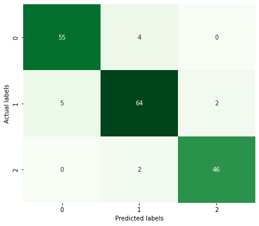

```python
display(Markdown('### 5.2.1 Clean Data'))

# clean data summary results
scf_clean = summary_confusion_matrix(clean_fold_matrix)
create_confusion_matrix_pretty(scf_clean)

display(Markdown('__Precision__: ' + str(precision(scf_clean))))
display(Markdown('__Recall__: ' + str(recall(scf_clean))))
```

5.2.2 Noisy Data

**Precision**: (0.8330779066666668, [0.81034483, 0.8, 0.88888889])

**Recall**: (0.82500464, [0.79661017, 0.84507042, 0.83333333])

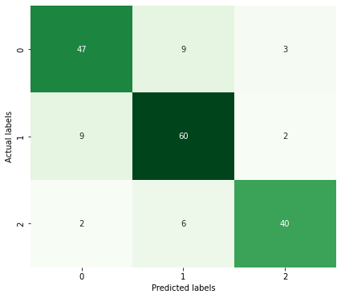

```python
display(Markdown('### 5.2.2 Noisy Data'))

# noisy data summary results
scf_noisy = summary_confusion_matrix(noisy_fold_matrix)
create_confusion_matrix_pretty(scf_noisy)

display(Markdown('__Precision__: ' + str(precision(scf_noisy))))
display(Markdown('__Recall__: ' + str(recall(scf_noisy))))
```

## 6. More questions

Now answer the following questions as fully as you can. The answers should be based on your implementation above. Write your answers in the Markdown cells below each question.

### Q3. Influence of noise

Do the best parameters change when noise is added to the data? Can you say that one parameter choice is better regardless of the data used?

Answer: There are two things to note when looking at the difference between the results on clean data and noisy data. Firstly, let's discuss the distance function. The euclidean distance algorithm dominates the results from the clean data, with only fold 5 showing a different distance function - manhattan. Whereas the noisy data alternates between manhattan and euclidean for the five folds - with manhattan actually coming out on top, being the best distance algorithm for three folds, as opposed to euclidean's two.

Secondly, when we look at the value of k, the number of nearest neighbours, we see that the most accourate number of neighbours for the clean data is quite low, ranging from 1 - for folds 2, 3 and 4 - to 3 - for fold 1. For noisy data, however, the results echo what we suggested during our exploratory data analysis - that a higher number of nearest neighbours might be needed to give us accurate results. For noisy data, the range of nearest neighbours is from 2 - for fold 3 - to 10 (the highest number of neighbours used in our analysis) for fold 2. We also see a 6 and a 7, for folds 4 and 5 respectively. The k value of 10 also gave us our most accurate number across all folds for noisy data, with an accuracy score of 0.92.

As for the best parameters regardless of the data used, the results would suggest that the euclidean algorith is the best distance function to use. For both data sets, it produced the highest accuracy scores, 0.97 and 0.92 for clean and noisy respectively (the 0.92 score for noisy data being reached using the maximum 10 nearest neighbours). For nearest neighbours, we could argue that a value of 3 for k is most successful. That value was awarded the most accurate score - 0.97 - for clean data, and the joint second most accurate score for noisy data - 0.83 - second only to, as stated numerous times, a value of 10.

Taking all of this into account, we could argue that the best parameter set, regardless of data, would be a value of 3 for k, and using the ecuclidean algorithm for the distance function.

### Q4. Tie break

Assume that you have selected the number of neighbours to be an even number, e.g., 2. For one of the neighbours, the suggested class is 1, and for the other neighbour the suggested class is 2. How would you break the tie? Write example pseudocode that does this.

Answer: I would suggest that there are two ways that we could break this tie. This most simple would be to ensure that the numbers of neighbours used is always odd, thus making a tie impossible. We could change the mykNN function like so:

```
def mykNN(X, y, X_, k, distance_function)
    # If k is even, add 1 to it:
    k_neighbours = k if not k % 2 else k + 1
    ...
```

However, this approach is a little too covert for my liking. If we were to hand our algorithm to someone else, someone who is only interested in the results and not in the implementation details, they may be confused as to why the results for k, being odd, and k + 1 were always identical.

I would argue that a better approach would be to compare the distances returned, and choose the class that has the closest value of the tied classes. Using pseudo code, we might change the predict function, in the mykNN algorithm, like so:

```
def predict(x)
    # ...

    # Get the most common labels as an array using a greedy algorith
    # to return all labels that are featured the highest number of times
    # rather than simply the first one
    most_common = greedy_algo(k_nearest_labels)

    # If there is more than one, we have a tie
    if (len(most_common) > 1):

        # Store the closest index
        closest = furthest_distance(distances)

        # Loop through most_common, getting the distance and comparing it to the last one
        for common in most_common:
            if distances[common] < distances[closest]
                closest = common

        # return the index of the closest distance
        return closest

     # There was only one
     else:
         return most_common[0]
```

### Q5. Beyond Wine

If you were to run your k-nn algorithm on a new dataset (e.g., the breast cancer dataset, or Iris), what considerations would you need to take into consideration? Outline any changes that might be needed to your code.

--- My results ---

Accuracy score: 0.9666666666666667

Precision: 0.9583333333333334

Recall: 0.9761904766666666

Precision (classes): [1.0, 1.0, 0.875]

Recall (classes): [1.0, 0.92857143, 1.0]

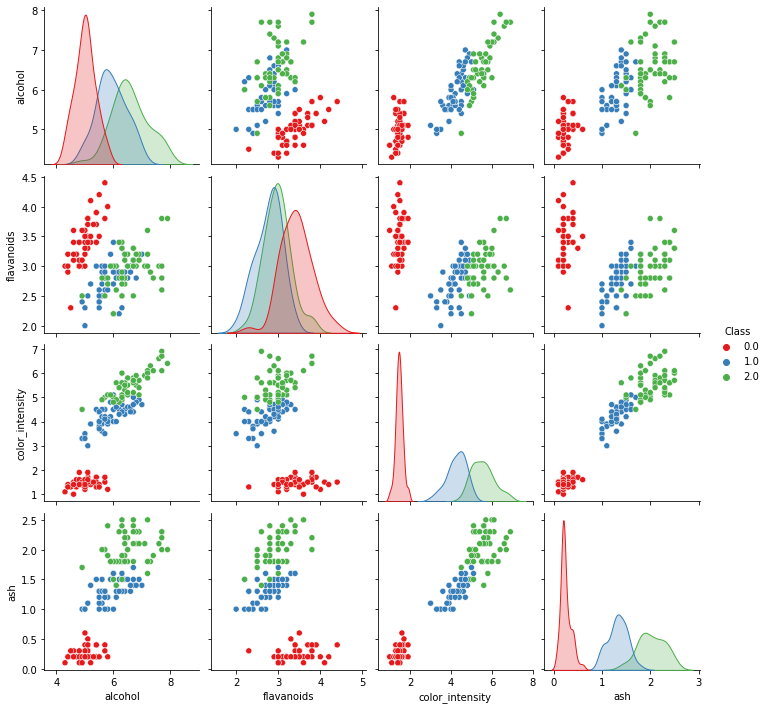

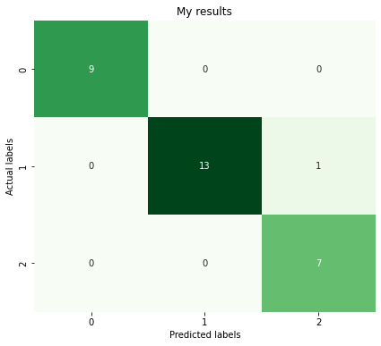

```python
# load data
iris=datasets.load_iris()

df_iris = pd.DataFrame(iris.data, columns = iris.feature_names )
iris_selected_features = ['sepal length (cm)','sepal width (cm)','petal length (cm)','petal width (cm)']

# Set up vars
iris_nearest_neighbours = 3 # The nearest neightbours to grab
iris_X, iris_y = df_iris[iris_selected_features].values, iris.target # The data we're using for KNN

# run the plotting function
myplotGrid(iris_X, iris_y, selected_features)

# Using custom function, create train and test data sets
iris_X_train, iris_X_test, iris_y_train, iris_y_test = train_test_split_data(iris_X, iris_y, test_size = 0.2)

# Invoke myKNN code
iris_y_ = mykNN(iris_X_train, iris_y_train, iris_X_test, 3, euclidean_distance)

# test evaluation code - My code
iris_cf = create_confusion_matrix(iris_y_test, iris_y_, iris_y) # Create confusion matrix to pass to later functions

display(Markdown('#### --- My results ---'))
display(Markdown('Accuracy score: ' + str(accuracy(iris_y_test, iris_y_))))
precision_avg, precision_all = precision(iris_cf)
recall_avg, recall_all = recall(iris_cf)
display(Markdown('Precision: ' + str(precision_avg)))
display(Markdown('Recall: ' + str(recall_avg)))
display(Markdown('Precision (classes):  ' + str(precision_all)))
display(Markdown('Recall (classes):  ' + str(recall_all)))

create_confusion_matrix_pretty(iris_cf, title ="My results")
```